# Predicting Loan Defaults and Loan Default Amounts

The goal of this assignment is to predict loan defaults and how much money would be defaulted.

```python
import math
import pandas as pd
import numpy as np
from operator import itemgetter


import matplotlib.pyplot as plt
import seaborn as sns


from sklearn.model_selection import train_test_split
import sklearn.metrics as metrics


from sklearn import tree
from sklearn.tree import _tree

from sklearn.ensemble import RandomForestRegressor
from sklearn.ensemble import RandomForestClassifier

from sklearn.ensemble import GradientBoostingRegressor
from sklearn.ensemble import GradientBoostingClassifier

from sklearn.linear_model import LinearRegression
from sklearn.linear_model import LogisticRegression
from sklearn.metrics import classification_report, confusion_matrix

from mlxtend.feature_selection import SequentialFeatureSelector as SFS
from mlxtend.plotting import plot_sequential_feature_selection as plot_sfs

import warnings
warnings.filterwarnings("ignore")

sns.set()
pd.set_option('display.max_rows', None)
pd.set_option('display.max_columns', None)
pd.set_option('display.width', None)
pd.set_option('display.max_colwidth', None)

TARGET_F = "TARGET_BAD_FLAG"
TARGET_A = "TARGET_LOSS_AMT"

df = pd.read_csv("HMEQ_loss.csv")
```

## Exploratory Data Analysis

The initial portion of this assignment was to do EDA on the dataset. Descriptive statistics of the dataset can be seen in the figure below.

```python
#Descriptive statistics for the data.
print("\n===============\n")
print("Descriptive Statistics:")
print(df.describe().T)
print("\n")
```

```
===============

Descriptive Statistics:
                  count           mean           std          min  \
TARGET_BAD_FLAG  5960.0       0.199497      0.399656     0.000000
TARGET_LOSS_AMT  1189.0   13414.576955  10839.455965   224.000000
LOAN             5960.0   18607.969799  11207.480417  1100.000000
MORTDUE          5442.0   73760.817200  44457.609458  2063.000000
VALUE            5848.0  101776.048741  57385.775334  8000.000000
YOJ              5445.0       8.922268      7.573982     0.000000
DEROG            5252.0       0.254570      0.846047     0.000000
DELINQ           5380.0       0.449442      1.127266     0.000000
CLAGE            5652.0     179.766275     85.810092     0.000000
NINQ             5450.0       1.186055      1.728675     0.000000
CLNO             5738.0      21.296096     10.138933     0.000000
DEBTINC          4693.0      33.779915      8.601746     0.524499

                          25%           50%            75%            max
TARGET_BAD_FLAG      0.000000      0.000000       0.000000       1.000000
TARGET_LOSS_AMT   5639.000000  11003.000000   17634.000000   78987.000000
LOAN             11100.000000  16300.000000   23300.000000   89900.000000
MORTDUE          46276.000000  65019.000000   91488.000000  399550.000000
VALUE            66075.500000  89235.500000  119824.250000  855909.000000
YOJ                  3.000000      7.000000      13.000000      41.000000
DEROG                0.000000      0.000000       0.000000      10.000000
DELINQ               0.000000      0.000000       0.000000      15.000000
CLAGE              115.116702    173.466667     231.562278    1168.233561
NINQ                 0.000000      1.000000       2.000000      17.000000
CLNO                15.000000     20.000000      26.000000      71.000000
DEBTINC             29.140031     34.818262      39.003141     203.312149
```

The summary does not tell us much but does show us that there is a large variation in the value for VALUE, or the value of the house. There also do seem to be outliers for TARGET_LOSS_AMT, LOAN, MORTDUE, VALUE, YOJ, CLAGE, NINQ, CLNO and DEBTINC. Based on the quartiles, it is possible that these variables are skewed to the right.

EDA of the categorical variables was done next. The results can be seen in the figure below. From these results, we can see that there is not a significant correlation between the reason for wanting a loan and whether it was defaulted. However, the amount lost on the loan for loans that defaulted was significantly higher for ‘DebtCon’ than ‘HomeImp’. For job type, people with the job classes ‘Sales’ and ‘Self’ were much more likely to default on their loan. The job class ‘Self’ also had a significantly higher average loss amount on the loan than the other job categories.

```python
#Creating lists for each variable type.
dt = df.dtypes
objList = []
intList = []
floatList = []
numList = []
for i in dt.index :
    if i in ([TARGET_F, TARGET_A]) : continue
    if dt[i] in (["str"]) : objList.append(i)
    if dt[i] in (["float64"]) : floatList.append(i)
    if dt[i] in (["int64"]) : intList.append(i)
    if dt[i] in (["int64","float64"]) : numList.append(i)
```

```python
#Exploring statistics for object variables.
print("===============\n")
print("EDA:\n\n")
print("CATEGORICAL VARIABLES\n\n")
for i in objList :
    print("Class = ", i)
    g = df.groupby(i)
    x = g[TARGET_F].mean()
    print("Default Prob", x)
    print(".................")
    x = g[TARGET_A].mean()
    print( "Loss Amount", x )
    print("===============\n\n")
```

```
===============

EDA:


CATEGORICAL VARIABLES


Class =  REASON
Default Prob REASON
DebtCon    0.189664
HomeImp    0.222472
Name: TARGET_BAD_FLAG, dtype: float64
.................
Loss Amount REASON
DebtCon    16005.163758
HomeImp     8388.090909
Name: TARGET_LOSS_AMT, dtype: float64
===============


Class =  JOB
Default Prob JOB
Mgr        0.233377
Office     0.131857
Other      0.231993
ProfExe    0.166144
Sales      0.348624
Self       0.300518
Name: TARGET_BAD_FLAG, dtype: float64
.................
Loss Amount JOB
Mgr        14141.536313
Office     13475.304000
Other      11570.102888
ProfExe    14660.966981
Sales      16421.447368
Self       22232.362069
Name: TARGET_LOSS_AMT, dtype: float64
===============
```

After looking at the categorical variables, integer variables were explored next. LOAN (loan amount) was the only integer variable. There was not a significant difference in loan amount between those who defaulted on their loan and those who didn’t, however, as expected, there was a strong correlation between loan amount and how much was lost on loans that defaulted.

```python
#Exploring statistics for integer variables.
print("===============\n")
print("INTEGER VARIABLES")
print("\n")
for i in intList :
    print("Variable=",i)
    g = df.groupby(TARGET_F)
    x = g[i].mean()
    print("Default Status",x)
    b = df[i].corr(df[TARGET_F])
    b = round(100*b,1)
    print("Default Correlation = ", b, "%")
    c = df[i].corr(df[TARGET_A])
    c = round(100*c,1)
    print("Loss Amount Correlation = ", c, "%")
    print("===============\n")
```

```
===============

INTEGER VARIABLES


Variable= LOAN
Default Status TARGET_BAD_FLAG
0    19028.107315
1    16922.119428
Name: LOAN, dtype: float64
Default Correlation =  -7.5 %
Loss Amount Correlation =  83.7 %
===============
```

Finally, float variables were explored. I will not print all the results, but an example of the output can be seen in the figure below. Among float variables there appeared to be strong correlation between loans being defaulted and the following variables: DEROG (derogatory marks on credit card), DELINQ (delinquencies on current credit report), and DEBTINC (debt to income ratio). These variables all had positive correlations with defaulting on the loans. There also appeared to be strong correlations between the amount lost on the loan and the following variables: MORTDUE (outstanding mortgage balance), VALUE (value of the house), DELINQ (delinquencies on current credit report), CLNO (number of credit lines), and DEBTINC (debt to income ratio). Again, these variables all had positive correlation with the amount defaulted.

```python
#Exploring statistics for float variables.
print("===============\n")
print("FLOAT VARIABLES" )
print("\n")
for i in floatList :
    print("Variable=",i)
    g = df.groupby(TARGET_F)
    x = g[i].mean()
    print("Default Status", x)
    b = df[i].corr(df[TARGET_F])
    b = round(100*b,1)
    print("Default Correlation = ", b, "%")
    c = df[i].corr(df[TARGET_A])
    c = round(100*c, 1)
    print("Loss Amount Correlation = ", c, "%")
    print("===============\n")
```

```
===============

FLOAT VARIABLES


Variable= MORTDUE
Default Status TARGET_BAD_FLAG
0    74829.249055
1    69460.452973
Name: MORTDUE, dtype: float64
Default Correlation =  -4.8 %
Loss Amount Correlation =  34.9 %
===============

Variable= VALUE
Default Status TARGET_BAD_FLAG
0    102595.921018
1     98172.846227
Name: VALUE, dtype: float64
Default Correlation =  -3.0 %
Loss Amount Correlation =  36.7 %
===============

Variable= YOJ
Default Status TARGET_BAD_FLAG
0    9.154941
1    8.027802
Name: YOJ, dtype: float64
Default Correlation =  -6.0 %
Loss Amount Correlation =  1.8 %
===============

Variable= DEROG
Default Status TARGET_BAD_FLAG
0    0.134217
1    0.707804
Name: DEROG, dtype: float64
Default Correlation =  27.6 %
Loss Amount Correlation =  9.5 %
===============
```

[output cut: 30 more lines]

```
0    21.317036
1    21.211268
Name: CLNO, dtype: float64
Default Correlation =  -0.4 %
Loss Amount Correlation =  40.0 %
===============

Variable= DEBTINC
Default Status TARGET_BAD_FLAG
0    33.253129
1    39.387645
Name: DEBTINC, dtype: float64
Default Correlation =  20.0 %
Loss Amount Correlation =  37.8 %
===============
```

Pie graphs were then constructed for the categorical variables and can be seen in the figures below. From the pie chart, it can be seen that the reason for most loans was ‘DebtCon’. There is not much to be taken of the pie chart for JOB other than the fact that ‘Other” was the most common job category.

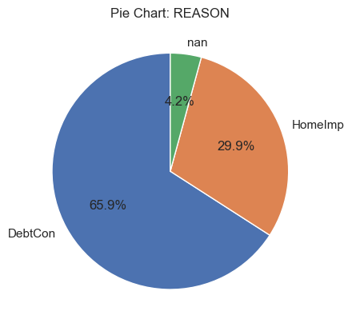

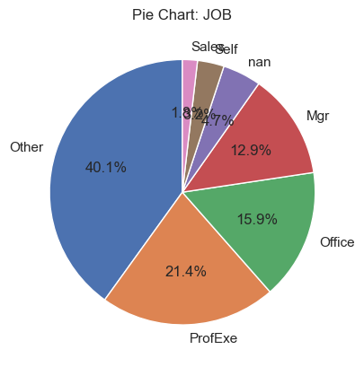

```python
#PLotting pie charts for object values.
for i in objList :
    x = df[i].value_counts(dropna=False)
    theLabels = x.axes[0].tolist()
    theSlices = list(x)
    plt.pie(theSlices,
            labels=theLabels,
             startangle = 90,
             shadow=False,
             autopct="%1.1f%%")
    plt.title("Pie Chart: " + i)
    plt.show()
    print("=====\n")
```

Next, histogram plots were constructed for the numerical variables. As can be seen in the figures below, and as previously hypothesized, these values are strongly skewed to the right.

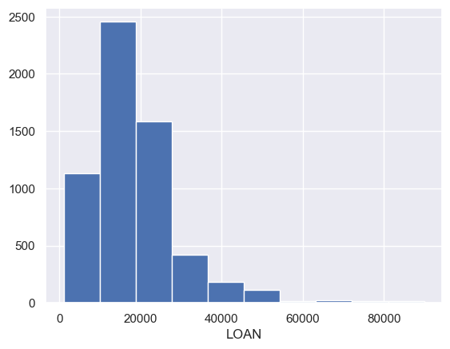

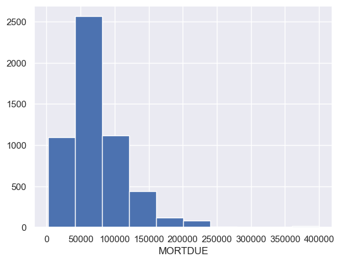

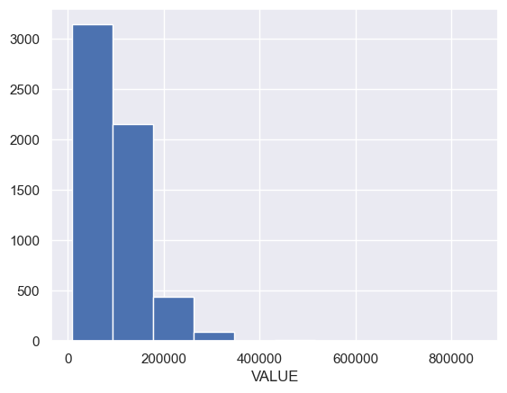

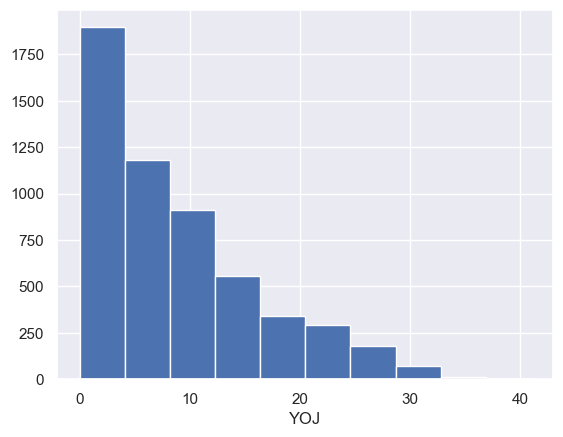

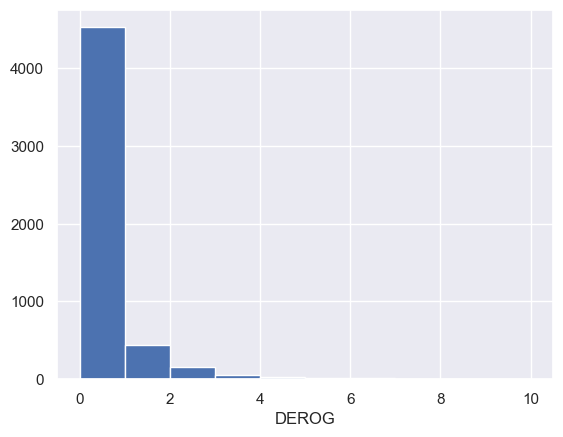

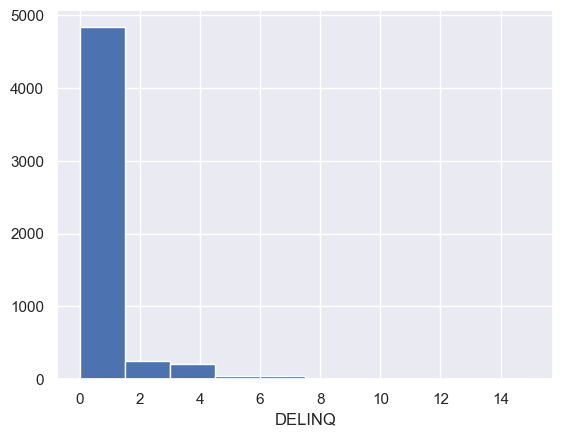

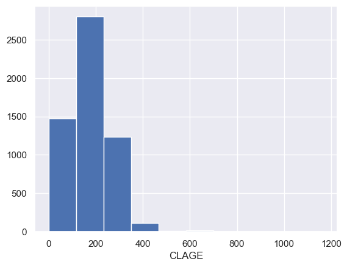

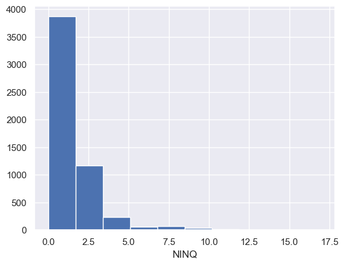

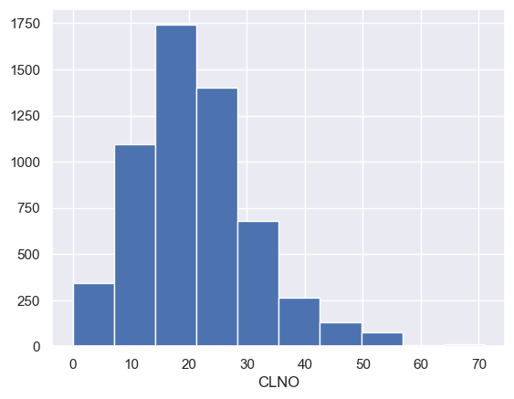

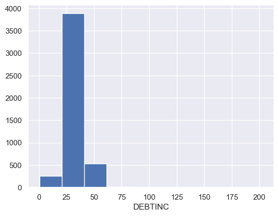

```python
#Plotting histogram for int values.
for i in intList:
    plt.hist(df[i])
    plt.xlabel(i)
    plt.show()

#Plotting histograms for float values.
for i in floatList :
    plt.hist(df[i])
    plt.xlabel(i)
    plt.show()
```

Finally, correlation plots were created for all variables and the amount lost on the loans. These plots can be seen below. Looking at the plots, it can. be observed that there appears to positive correlations between amount lost on the loan and the variables LOAN, MORT DUE, CLNO and DEBTINC.

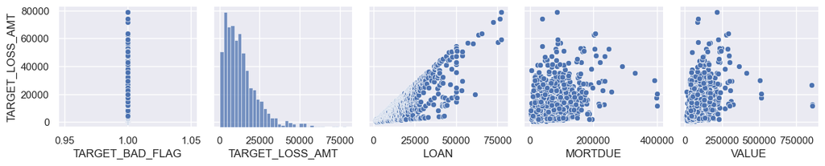

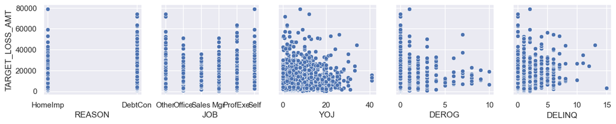

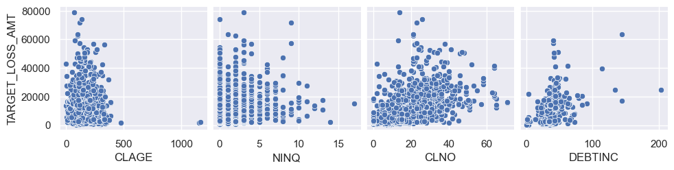

```python
#Looking for relationships between the variables and the loss amount.
for i in range(0, len(df.columns),5):
    sns.pairplot(df, y_vars = ['TARGET_LOSS_AMT'], x_vars =df.columns[i:i+5])
```

## Data Cleaning and Preparation

After exploring the data, the data needed to be cleaned and prepared. First, missing data was filled in with the category "MISSING", binary variables were one hot encoded.

```python
# dt = df.dtypes

# objList = []
# numList = []
# for i in dt.index:
#     if i in ([TARGET_F, TARGET_A ]) : continue
#     if dt[i] in (["object"]) : objList.append(i)
#     if dt[i] in (["float64","int64"]) : numList.append(i)

#Filling in missing data with the category "Missing"
"""
FILL IN MISSING WITH THE CATEGORY "MISSING"
"""
for i in objList :
    if df[i].isna().sum() == 0 : continue
    NAME = "IMP_"+i
    df[NAME] = df[i]
    df[NAME] = df[NAME].fillna("MISSING")
    g = df.groupby( NAME )
    df = df.drop(i, axis=1)

dt = df.dtypes
objList = []
for i in dt.index :
    if i in ([TARGET_F, TARGET_A]) : continue
    if dt[i] in (["str"]) : objList.append(i)
```

Next, binary variables were one hot encoded.

```python
#One hot encoding binary variables.
df["IMP_REASON_DebtCon_Yes"] = (df["IMP_REASON"].isin(["DebtCon"])+0)
df = df.drop("IMP_REASON", axis=1)
```

```python
dt = df.dtypes
objList = []
for i in dt.index:
    if i in ([TARGET_F, TARGET_A]) : continue
    if dt[i] in (["str"]) : objList.append(i)

for i in objList:
    thePrefix = "z_" + i
    y = pd.get_dummies(df[i], prefix=thePrefix, dummy_na=False)
    df = pd.concat([df, y], axis=1)
    #df = df.drop(i, axis=1)
```

Missing numerical values were filled with the median of that specific variable, and flag variables were created to indicate if the value was missing for each record.

```python
#Imputing all missing numerical data and creating a flag variable to indicate if the value was missing.
for i in numList :
    if df[i].isna().sum() == 0 : continue
    FLAG = "M_" + i
    IMP = "IMP_" + i
    df[FLAG] = df[i].isna() + 0
    df[IMP] = df[i]
    df.loc[df[IMP].isna(), IMP] = df[i].median()
    df = df.drop(i, axis=1)
```

Outliers were then removed, where an outlier is defined as the mean plus or minus three standard deviations.

```python
"""
Remove Outliers
"""


dt = df.dtypes
numList = []
for i in dt.index:
    #print(i, dt[i])
    if i in ([TARGET_F, TARGET_A ]) : continue
    if dt[i] in (["float64","int64"]) : numList.append(i)

# for i in numList:
#     print(i)
```

```python
for i in numList:
    theMean = df[i].mean()
    theSD = df[i].std()
    theMax = df[i].max()
    theCutoff = round(theMean + 3*theSD)
    if theMax < theCutoff : continue
    FLAG = "O_" + i
    TRUNC = "TRUNC_" + i
    df[FLAG] = (df[i] > theCutoff)+ 0
    df[TRUNC] = df[ i ]
    df.loc[ df[TRUNC] > theCutoff, TRUNC] = theCutoff
    df = df.drop(i, axis=1 )
```

```python
for i in objList:
    df = df.drop(i, axis=1)
```

```python
"""
SPLIT DATA
"""

X = df.copy()
X = X.drop(TARGET_F, axis=1)
X = X.drop(TARGET_A, axis=1)

Y = df[[TARGET_F, TARGET_A]]

X_train, X_test, Y_train, Y_test = train_test_split(X, Y, train_size=0.8, test_size=0.2, random_state=2)
```

Finally, the data was split using an 80/20 train to test ratio.

```python
F = ~ Y_train[TARGET_A].isna()
W_train = X_train[F].copy()
Z_train = Y_train[F].copy()

F = ~ Y_test[TARGET_A].isna()
W_test = X_test[F].copy()
Z_test = Y_test[F].copy()
```

## Tree Based Models

The next portion of the assignment was to create tree based models to predict loan defaults and default amounts. First, the model accuracy metrics were defined.

```python
"""
MODEL ACCURACY METRICS
"""

def getProbAccuracyScores(NAME, MODEL, X, Y) :
    pred = MODEL.predict(X)
    probs = MODEL.predict_proba(X)
    acc_score = metrics.accuracy_score(Y, pred)
    p1 = probs[:,1]
    fpr, tpr, threshold = metrics.roc_curve(Y, p1)
    auc = metrics.auc(fpr,tpr)
    return [NAME, acc_score, fpr, tpr, auc]

def print_ROC_Curve(TITLE, LIST) :
    fig = plt.figure(figsize=(6,4))
    plt.title( TITLE )
    for theResults in LIST :
        NAME = theResults[0]
        fpr = theResults[2]
        tpr = theResults[3]
        auc = theResults[4]
        theLabel = "AUC " + NAME + ' %0.2f' % auc
        plt.plot(fpr, tpr, label = theLabel)
    plt.legend(loc = 'lower right')
    plt.plot([0, 1], [0, 1],'r--')
    plt.xlim([0, 1])
    plt.ylim([0, 1])
    plt.ylabel('True Positive Rate')
    plt.xlabel('False Positive Rate')
    plt.show()

def print_Accuracy(TITLE, LIST) :
    print( TITLE )
    print( "======" )
    for theResults in LIST :
        NAME = theResults[0]
        ACC = theResults[1]
        print( NAME, " = ", ACC )
    print( "------\n\n" )

def getAmtAccuracyScores(NAME, MODEL, X, Y) :
    pred = MODEL.predict(X)
    MEAN = Y.mean()
    RMSE = math.sqrt( metrics.mean_squared_error(Y, pred))
    return [NAME, RMSE, MEAN]
```

Decision trees for both the default probability and the loss amount were created. The ROC Curve for predicting defaults and the accuracy for both models can be seen below.

```python
"""
DECISION TREE
"""

def getTreeVars(TREE, varNames) :
    tree_ = TREE.tree_
    varName = [varNames[i] if i != _tree.TREE_UNDEFINED else "undefined!" for i in tree_.feature]

    nameSet = set()
    for i in tree_.feature :
        if i != _tree.TREE_UNDEFINED :
            nameSet.add(i)
    nameList = list(nameSet)
    parameter_list = list()
    for i in nameList :
        parameter_list.append(varNames[i])
    return parameter_list
```

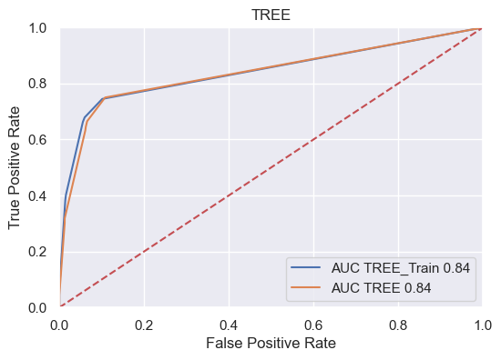

```
TREE CLASSIFICATION ACCURACY
======
TREE_Train  =  0.8888422818791947
TREE  =  0.8766778523489933
------
```

```python
#DEFAULT PROBABILITY

WHO = "TREE"

DFT = tree.DecisionTreeClassifier(max_depth=3)
# fm01_Tree = tree.DecisionTreeClassifier()
DFT = DFT.fit(X_train, Y_train[TARGET_F])

TRAIN_DFT = getProbAccuracyScores(WHO + "_Train", DFT, X_train, Y_train[TARGET_F])
TEST_DFT = getProbAccuracyScores(WHO, DFT, X_test, Y_test[TARGET_F])

feature_cols = list(X.columns.values)
tree.export_graphviz(DFT,out_file='tree_f.txt',filled=True, rounded=True, feature_names = feature_cols, impurity=False, class_names=["Good","Bad"])
vars_tree_flag = getTreeVars(DFT, feature_cols)

print_ROC_Curve(WHO,[TRAIN_DFT, TEST_DFT])
print_Accuracy(WHO + " CLASSIFICATION ACCURACY", [TRAIN_DFT, TEST_DFT])
```

```python
# DEFAULT AMOUNTS

AMT = tree.DecisionTreeRegressor(max_depth= 3)
AMT = AMT.fit(W_train, Z_train[TARGET_A])

TRAIN_AMT = getAmtAccuracyScores(WHO + "_Train", AMT, W_train, Z_train[TARGET_A])
TEST_AMT = getAmtAccuracyScores(WHO, AMT, W_test, Z_test[TARGET_A])
print_Accuracy(WHO + " RMSE ACCURACY", [TRAIN_AMT, TEST_AMT ])

feature_cols = list(X.columns.values)
vars_tree_amt = getTreeVars(AMT, feature_cols)
tree.export_graphviz(AMT,out_file='tree_a.txt',filled=True, rounded=True, feature_names = feature_cols, impurity=False, precision=0  )
```

```
TREE RMSE ACCURACY
======
TREE_Train  =  5432.762057492914
TREE  =  6933.346719462516
------
```

```python
TREE_DFT = TEST_DFT.copy()
TREE_AMT = TEST_AMT.copy()
```

```python
"""
RANDOM FOREST
"""

def getEnsembleTreeVars(ENSTREE, varNames) :
   importance = ENSTREE.feature_importances_
   index = np.argsort(importance)
   theList = []
   for i in index :
       imp_val = importance[i]
       if imp_val > np.average(ENSTREE.feature_importances_) :
           v = int(imp_val/np.max(ENSTREE.feature_importances_) * 100)
           theList.append((varNames[i], v))
   theList = sorted(theList,key=itemgetter(1),reverse=True)
   return theList
```

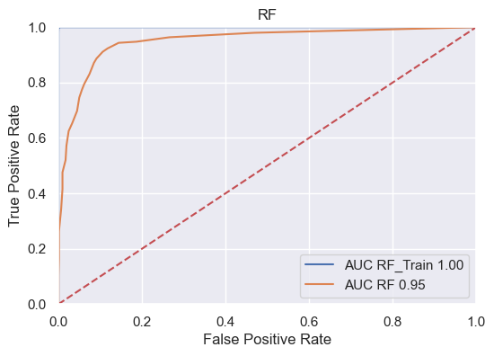

```
RF CLASSIFICATION ACCURACY
======
RF_Train  =  0.9991610738255033
RF  =  0.9018456375838926
------
```

```python
# DEFAULT PROBABILITY

WHO = "RF"

DFT = RandomForestClassifier(n_estimators = 25, random_state=1)
DFT = DFT.fit(X_train, Y_train[TARGET_F])

TRAIN_DFT = getProbAccuracyScores(WHO + "_Train", DFT, X_train, Y_train[TARGET_F])
TEST_DFT = getProbAccuracyScores(WHO, DFT, X_test, Y_test[TARGET_F])

print_ROC_Curve(WHO, [TRAIN_DFT, TEST_DFT] )
print_Accuracy(WHO + " CLASSIFICATION ACCURACY", [TRAIN_DFT, TEST_DFT])


feature_cols = list(X.columns.values )
vars_RF_flag = getEnsembleTreeVars(DFT, feature_cols)
```

```python
# DEFAULT AMOUNTS

AMT = RandomForestRegressor(n_estimators = 25, random_state=1)
AMT = AMT.fit(W_train, Z_train[TARGET_A])

TRAIN_AMT = getAmtAccuracyScores(WHO + "_Train", AMT, W_train, Z_train[TARGET_A])
TEST_AMT = getAmtAccuracyScores(WHO, AMT, W_test, Z_test[TARGET_A])
print_Accuracy(WHO + " RMSE ACCURACY", [TRAIN_AMT, TEST_AMT ])

feature_cols = list(X.columns.values)
vars_RF_amt = getEnsembleTreeVars(AMT, feature_cols)
```

```
RF RMSE ACCURACY
======
RF_Train  =  1320.073498983602
RF  =  4695.811183058997
------
```

```python
RF_DFT = TEST_DFT.copy()
RF_AMT = TEST_AMT.copy()
```

After random forests, gradient boosting to create another model. A ROC curve for the model can be seen below. The model has an AUC value of 0.94 for the test data, slightly below the 0.95 value for the random forest model.

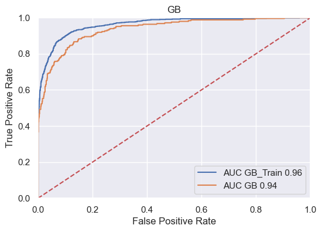

```
GB CLASSIFICATION ACCURACY
======
GB_Train  =  0.9238674496644296
GB  =  0.9018456375838926
------
```

```python
"""
GRADIENT BOOSTING
"""
WHO = "GB"

DFT = GradientBoostingClassifier(random_state=1)
DFT = DFT.fit(X_train, Y_train[TARGET_F])

TRAIN_DFT = getProbAccuracyScores(WHO + "_Train", DFT, X_train, Y_train[ TARGET_F])
TEST_DFT = getProbAccuracyScores(WHO, DFT, X_test, Y_test[TARGET_F])

print_ROC_Curve(WHO, [TRAIN_DFT, TEST_DFT] )
print_Accuracy(WHO + " CLASSIFICATION ACCURACY", [TRAIN_DFT, TEST_DFT])


feature_cols = list(X.columns.values )
vars_GB_flag = getEnsembleTreeVars(DFT, feature_cols)
```

```python
# DEFAULT AMOUNTS

AMT = GradientBoostingRegressor(random_state=1)
AMT = AMT.fit(W_train, Z_train[TARGET_A])

TRAIN_AMT = getAmtAccuracyScores(WHO + "_Train", AMT, W_train, Z_train[TARGET_A])
TEST_AMT = getAmtAccuracyScores(WHO, AMT, W_test, Z_test[TARGET_A])
print_Accuracy(WHO + " RMSE ACCURACY", [TRAIN_AMT, TEST_AMT ])

feature_cols = list(X.columns.values)
vars_GB_amt = getEnsembleTreeVars(AMT, feature_cols)
```

```
GB RMSE ACCURACY
======
GB_Train  =  1198.545135283387
GB  =  4176.186787949678
------
```

```python
GB_DFT = TEST_DFT.copy()
GB_AMT = TEST_AMT.copy()
```

## Regression Based Models

The next portion of the assignment was to create regression based models to predict loan defaults and default amounts. First, the model accuracy metrics were defined.

```python
def getCoefLogit(MODEL, TRAIN_DATA) :
    varNames = list(TRAIN_DATA.columns.values)
    coef_dict = {}
    coef_dict["INTERCEPT"] = MODEL.intercept_[0]
    for coef, feat in zip(MODEL.coef_[0],varNames):
        coef_dict[feat] = coef
    print("\nDEFAULT")
    print("---------")
    print("Total Variables: ", len(coef_dict))
    for i in coef_dict:
        print(i, " = ", coef_dict[i])



def getCoefLinear(MODEL, TRAIN_DATA) :
    varNames = list(TRAIN_DATA.columns.values)
    coef_dict = {}
    coef_dict["INTERCEPT"] = MODEL.intercept_
    for coef, feat in zip(MODEL.coef_,varNames):
        coef_dict[feat] = coef
    print("\nDEFAULT AMOUNT")
    print("---------")
    print("Total Variables: ", len(coef_dict))
    for i in coef_dict :
        print(i, " = ", coef_dict[i])
```

A logistic regression model was built to determine the probability of a loan default using all the variables. A ROC curve for the model can be seen below. The AUC for the training data is greater than for the test data, but not by much. The model was 89.5% accurate for the training set and 88.1% accurate for the test set.

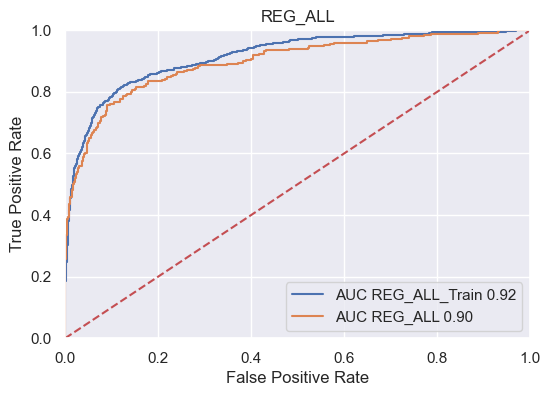

```
REG_ALL CLASSIFICATION ACCURACY
======
REG_ALL_Train  =  0.8947147651006712
REG_ALL  =  0.8808724832214765
------
```

```python
"""
REGRESSION ALL VARIABLES
"""

WHO = "REG_ALL"

DFT = LogisticRegression(solver='newton-cg', max_iter=1000)
DFT = DFT.fit(X_train, Y_train[TARGET_F])

TRAIN_DFT = getProbAccuracyScores(WHO + "_Train", DFT, X_train, Y_train[TARGET_F])
TEST_DFT = getProbAccuracyScores(WHO, DFT, X_test, Y_test[TARGET_F])

print_ROC_Curve(WHO, [TRAIN_DFT, TEST_DFT])
print_Accuracy(WHO + " CLASSIFICATION ACCURACY", [TRAIN_DFT, TEST_DFT] )
```

A linear regression model was built to predict the loss amount on loans that defaulted based on all variables.

```python
# DEFAULT AMOUNTS

AMT = LinearRegression()
AMT = AMT.fit(W_train, Z_train[TARGET_A])

TRAIN_AMT = getAmtAccuracyScores(WHO + "_Train", AMT, W_train, Z_train[TARGET_A])
TEST_AMT = getAmtAccuracyScores(WHO, AMT, W_test, Z_test[TARGET_A] )
print_Accuracy(WHO + " RMSE ACCURACY", [TRAIN_AMT, TEST_AMT])


varNames = list(X_train.columns.values)

# REG_ALL_DFT_COEF = getCoefLogit(DFT, X_train)
# REG_ALL_AMT_COEF = getCoefLinear(AMT, X_train)
```

```
REG_ALL RMSE ACCURACY
======
REG_ALL_Train  =  3290.959712407766
REG_ALL  =  4523.648027613844
------
```

```python
REG_ALL_DFT = TEST_DFT.copy()
REG_ALL_AMT = TEST_AMT.copy()
```

Next, regression models were created using the varaibles selected by the different tree based models above. I'll avoid showing all the output so the models can be compared at the end. The variables used for each model are also displayed.

```python
"""
REGRESSION DECISION TREE
"""

WHO = "REG_TREE"

DFT = LogisticRegression( solver='newton-cg', max_iter=1000)
DFT = DFT.fit(X_train[vars_tree_flag], Y_train[ TARGET_F])

TRAIN_DFT = getProbAccuracyScores(WHO + "_Train", DFT, X_train[vars_tree_flag], Y_train[TARGET_F])
TEST_DFT = getProbAccuracyScores(WHO, DFT, X_test[vars_tree_flag], Y_test[TARGET_F])

# print_ROC_Curve(WHO, [TRAIN_DFT, TEST_DFT])
# print_Accuracy(WHO + " CLASSIFICATION ACCURACY",[TRAIN_DFT, TEST_DFT])
```

```python
# DEFAULT AMOUNTS

AMT = LinearRegression()
AMT = AMT.fit(W_train[vars_tree_amt], Z_train[TARGET_A])

TRAIN_AMT = getAmtAccuracyScores(WHO + "_Train", AMT, W_train[vars_tree_amt], Z_train[TARGET_A])
TEST_AMT = getAmtAccuracyScores(WHO, AMT, W_test[vars_tree_amt], Z_test[TARGET_A])
print_Accuracy(WHO + " RMSE ACCURACY", [TRAIN_AMT, TEST_AMT])


varNames = list(X_train.columns.values)

#REG_TREE_DFT_COEF = getCoefLogit(DFT, X_train[vars_tree_flag])
#REG_TREE_AMT_COEF = getCoefLinear(AMT, X_train[vars_tree_amt])
```

```
REG_TREE RMSE ACCURACY
======
REG_TREE_Train  =  4779.396533832553
REG_TREE  =  5459.643365660541
------
```

```python
REG_TREE_DFT = TEST_DFT.copy()
REG_TREE_AMT = TEST_AMT.copy()
```

```python
"""
REGRESSION RANDOM FOREST
"""

WHO = "REG_RF"


print("\n\n")
RF_flag = []
for i in vars_RF_flag:
    print(i)
    theVar = i[0]
    RF_flag.append(theVar)

print("\n\n")
RF_amt = []
for i in vars_RF_amt:
    print(i)
    theVar = i[0]
    RF_amt.append(theVar)
```

```
('TRUNC_M_DEBTINC', 100)
('TRUNC_IMP_DEBTINC', 71)
('TRUNC_IMP_CLAGE', 45)
('TRUNC_LOAN', 40)
('TRUNC_IMP_DELINQ', 38)
('TRUNC_IMP_VALUE', 36)
('TRUNC_IMP_MORTDUE', 36)
('TRUNC_IMP_CLNO', 32)
('TRUNC_IMP_YOJ', 28)
('TRUNC_IMP_NINQ', 20)
('TRUNC_IMP_DEROG', 20)



('TRUNC_LOAN', 100)
('TRUNC_IMP_CLNO', 9)
('TRUNC_IMP_DEBTINC', 5)
('TRUNC_M_DEBTINC', 5)
('TRUNC_IMP_CLAGE', 3)
```

```python
DFT = LogisticRegression(solver='newton-cg', max_iter=1000)
DFT = DFT.fit(X_train[RF_flag], Y_train[TARGET_F])

TRAIN_DFT = getProbAccuracyScores(WHO + "_Train", DFT, X_train[RF_flag], Y_train[TARGET_F])
TEST_DFT = getProbAccuracyScores(WHO, DFT, X_test[RF_flag], Y_test[TARGET_F])

# print_ROC_Curve(WHO, [TRAIN_DFT, TEST_DFT] )
# print_Accuracy(WHO + " CLASSIFICATION ACCURACY", [TRAIN_DFT, TEST_DFT])
```

```python
# DEFAULT AMOUNTS

AMT = LinearRegression()
AMT = AMT.fit(W_train[RF_amt], Z_train[TARGET_A])

TRAIN_AMT = getAmtAccuracyScores(WHO + "_Train", AMT, W_train[RF_amt], Z_train[TARGET_A])
TEST_AMT = getAmtAccuracyScores(WHO, AMT, W_test[RF_amt], Z_test[TARGET_A])
print_Accuracy(WHO + " RMSE ACCURACY", [ TRAIN_AMT, TEST_AMT ])


REG_RF_DFT_COEF = getCoefLogit(DFT, X_train[RF_flag])
REG_RF_AMT_COEF = getCoefLinear(AMT, X_train[RF_amt])
```

```
REG_RF RMSE ACCURACY
======
REG_RF_Train  =  4210.648515985967
REG_RF  =  4936.21358051146
------



DEFAULT
---------
Total Variables:  12
INTERCEPT  =  -4.776916452291309
TRUNC_M_DEBTINC  =  2.6936287398052996
TRUNC_IMP_DEBTINC  =  0.09591918577612851
TRUNC_IMP_CLAGE  =  -0.006497787129533897
TRUNC_LOAN  =  -6.958766585686775e-06
TRUNC_IMP_DELINQ  =  0.7182512561753069
TRUNC_IMP_VALUE  =  6.052935653532418e-08
TRUNC_IMP_MORTDUE  =  -1.8758613908941483e-07
TRUNC_IMP_CLNO  =  -0.013084746809480024
TRUNC_IMP_YOJ  =  -0.01194934958974684
TRUNC_IMP_NINQ  =  0.1127423658978209
TRUNC_IMP_DEROG  =  0.6628206720172155

DEFAULT AMOUNT
---------
Total Variables:  6
INTERCEPT  =  -12859.829208040166
TRUNC_LOAN  =  0.8343191278860596
TRUNC_IMP_CLNO  =  274.5333393350717
TRUNC_IMP_DEBTINC  =  196.30485919039037
TRUNC_M_DEBTINC  =  5556.796082789425
TRUNC_IMP_CLAGE  =  -27.05802787356039
```

```python
REG_RF_DFT = TEST_DFT.copy()
REG_RF_AMT = TEST_AMT.copy()
```

```python
"""
REGRESSION GRADIENT BOOSTING
"""

WHO = "REG_GB"


print("\n\n")
GB_flag = []
for i in vars_GB_flag:
    print(i)
    theVar = i[0]
    GB_flag.append(theVar)

print("\n\n")
GB_amt = []
for i in vars_GB_amt:
    print(i)
    theVar = i[0]
    GB_amt.append(theVar)
```

```
('TRUNC_M_DEBTINC', 100)
('TRUNC_IMP_DEBTINC', 29)
('TRUNC_IMP_CLAGE', 16)
('TRUNC_IMP_DELINQ', 16)
('O_M_VALUE', 7)
('TRUNC_IMP_DEROG', 6)



('TRUNC_LOAN', 100)
('TRUNC_IMP_CLNO', 10)
('TRUNC_M_DEBTINC', 6)
('TRUNC_IMP_DEBTINC', 4)
('TRUNC_IMP_CLAGE', 2)
```

```python
DFT = LogisticRegression(solver='newton-cg', max_iter=1000)
DFT = DFT.fit(X_train[GB_flag], Y_train[TARGET_F])

TRAIN_DFT = getProbAccuracyScores(WHO + "_Train", DFT, X_train[GB_flag], Y_train[TARGET_F])
TEST_DFT = getProbAccuracyScores(WHO, DFT, X_test[GB_flag], Y_test[TARGET_F])

# print_ROC_Curve(WHO, [TRAIN_DFT, TEST_DFT] )
# print_Accuracy(WHO + " CLASSIFICATION ACCURACY", [TRAIN_DFT, TEST_DFT])
```

```python
# DEFAULT AMOUNTS

AMT = LinearRegression()
AMT = AMT.fit( W_train[GB_amt], Z_train[TARGET_A] )

TRAIN_AMT = getAmtAccuracyScores(WHO + "_Train", AMT, W_train[GB_amt], Z_train[TARGET_A])
TEST_AMT = getAmtAccuracyScores(WHO, AMT, W_test[GB_amt], Z_test[TARGET_A])
print_Accuracy(WHO + " RMSE ACCURACY", [TRAIN_AMT, TEST_AMT])

REG_GB_DFT_COEF = getCoefLogit(DFT, X_train[GB_flag])
REG_GB_AMT_COEF = getCoefLinear(AMT, X_train[GB_amt])
```

```
REG_GB RMSE ACCURACY
======
REG_GB_Train  =  4210.648515985967
REG_GB  =  4936.213580511462
------



DEFAULT
---------
Total Variables:  7
INTERCEPT  =  -5.333445287324823
TRUNC_M_DEBTINC  =  2.7205070668325635
TRUNC_IMP_DEBTINC  =  0.10432386665456338
TRUNC_IMP_CLAGE  =  -0.007529444370848859
TRUNC_IMP_DELINQ  =  0.6761012397379926
O_M_VALUE  =  3.4738828149772876
TRUNC_IMP_DEROG  =  0.6743558435549386

DEFAULT AMOUNT
---------
Total Variables:  6
INTERCEPT  =  -12859.829208040137
TRUNC_LOAN  =  0.8343191278860596
TRUNC_IMP_CLNO  =  274.5333393350722
TRUNC_M_DEBTINC  =  5556.796082789417
TRUNC_IMP_DEBTINC  =  196.3048591903904
TRUNC_IMP_CLAGE  =  -27.058027873560633
```

```python
REG_GB_DFT = TEST_DFT.copy()
REG_GB_AMT = TEST_AMT.copy()
```

## Neural Networks

```python
# conda install tensorflow
import tensorflow as tf

from sklearn.preprocessing import MinMaxScaler
theScaler = MinMaxScaler()
theScaler.fit(X_train)
```

[output not shown]

```
MinMaxScaler()
```

```python
def get_TF_ProbAccuracyScores(NAME, MODEL, X, Y) :
    probs = MODEL.predict(X)
    pred_list = []
    for p in probs :
        pred_list.append(np.argmax(p))
    pred = np.array(pred_list)
    acc_score = metrics.accuracy_score(Y, pred)
    p1 = probs[:,1]
    fpr, tpr, threshold = metrics.roc_curve(Y, p1)
    auc = metrics.auc(fpr,tpr)
    return [NAME, acc_score, fpr, tpr, auc]
```

```python
WHO = "Tensor_Flow_RELU_One_Layer"

U_train = theScaler.transform(X_train)
U_test = theScaler.transform(X_test)

U_train = pd.DataFrame(U_train)
U_test = pd.DataFrame(U_test)

U_train.columns = list(X_train.columns.values)
U_test.columns = list(X_train.columns.values)

U_train = U_train[GB_flag]
U_test = U_test[GB_flag]
```

```python
F_theShapeSize = U_train.shape[1]
F_theActivation = tf.keras.activations.relu
F_theLossMetric = tf.keras.losses.SparseCategoricalCrossentropy()
F_theOptimizer = tf.keras.optimizers.Adam()
F_theEpochs = 100

F_theUnits = int(2*F_theShapeSize / 3)
```

```python
F_LAYER_01 = tf.keras.layers.Dense(units=F_theUnits, activation=F_theActivation, input_dim=F_theShapeSize)
#F_LAYER_DROP = tf.keras.layers.Dropout(0.2)
#F_LAYER_02 = tf.keras.layers.Dense(units=F_theUnits, activation=F_theActivation)
F_LAYER_OUTPUT = tf.keras.layers.Dense(units=2, activation=tf.keras.activations.softmax)
```

```python
DFT = tf.keras.Sequential()
DFT.add(F_LAYER_01)
# DFT.add(F_LAYER_DROP)
# DFT.add(F_LAYER_02)
DFT.add(F_LAYER_OUTPUT)
DFT.compile(loss=F_theLossMetric, optimizer=F_theOptimizer)
DFT.fit(U_train, Y_train[TARGET_F], epochs=F_theEpochs, verbose=False)
```

```
<keras.src.callbacks.history.History at 0x133574e90>
```

```
149/149 ━━━━━━━━━━━━━━━━━━━━ 0s 1ms/step
38/38 ━━━━━━━━━━━━━━━━━━━━ 0s 2ms/step
```

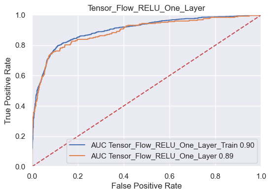

```
Tensor_Flow_RELU_One_Layer CLASSIFICATION ACCURACY
======
Tensor_Flow_RELU_One_Layer_Train  =  0.8844379194630873
Tensor_Flow_RELU_One_Layer  =  0.8800335570469798
------
```

```python
TRAIN_DFT = get_TF_ProbAccuracyScores(WHO + "_Train", DFT, U_train, Y_train[TARGET_F])
TEST_DFT = get_TF_ProbAccuracyScores(WHO, DFT, U_test, Y_test[TARGET_F])

print_ROC_Curve(WHO, [TRAIN_DFT, TEST_DFT] )
print_Accuracy(WHO + " CLASSIFICATION ACCURACY", [TRAIN_DFT, TEST_DFT])
```

```python
V_train = theScaler.transform(W_train)
V_test = theScaler.transform(W_test)

V_train = pd.DataFrame(V_train)
V_test = pd.DataFrame(V_test)

V_train.columns = list(W_train.columns.values)
V_test.columns = list(W_train.columns.values)

V_train = V_train[GB_amt]
V_test = V_test[GB_amt]
```

```python
A_theShapeSize = V_train.shape[1]
A_theActivation = tf.keras.activations.relu
A_theLossMetric = tf.keras.losses.MeanSquaredError()
A_theOptimizer = tf.keras.optimizers.Adam()
A_theEpochs = 800

A_theUnits = int(2*A_theShapeSize)
```

```python
A_LAYER_01 = tf.keras.layers.Dense(units=A_theUnits, activation=A_theActivation, input_dim=A_theShapeSize)
# A_LAYER_DROP = tf.keras.layers.Dropout(0.2)
# A_LAYER_02 = tf.keras.layers.Dense(units=A_theUnits, activation=A_theActivation)
A_LAYER_OUTPUT = tf.keras.layers.Dense(units=1, activation=tf.keras.activations.linear)
```

```python
AMT = tf.keras.Sequential()
AMT.add(A_LAYER_01)
# AMT.add(A_LAYER_DROP)
# AMT.add(A_LAYER_02)
AMT.add(A_LAYER_OUTPUT)
AMT.compile(loss=A_theLossMetric, optimizer=A_theOptimizer)
AMT.fit(V_train, Z_train[TARGET_A], epochs=A_theEpochs, verbose=False)
```

```
<keras.src.callbacks.history.History at 0x133758210>
```

```python
TRAIN_AMT = getAmtAccuracyScores(WHO + "_Train", AMT, V_train[GB_amt], Z_train[TARGET_A])
TEST_AMT = getAmtAccuracyScores(WHO, AMT, V_test[GB_amt], Z_test[TARGET_A])
print_Accuracy(WHO + " RMSE ACCURACY", [TRAIN_AMT, TEST_AMT])

TF_DFT_RELU_One_Layer = TEST_DFT.copy()
TF_AMT_RELU_One_Layer = TEST_AMT.copy()
```

```
30/30 ━━━━━━━━━━━━━━━━━━━━ 0s 2ms/step
8/8 ━━━━━━━━━━━━━━━━━━━━ 0s 3ms/step
Tensor_Flow_RELU_One_Layer RMSE ACCURACY
======
Tensor_Flow_RELU_One_Layer_Train  =  9574.109810590766
Tensor_Flow_RELU_One_Layer  =  9572.61854180645
------
```

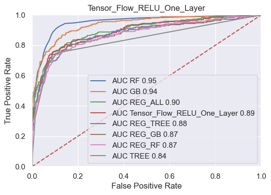

```
ALL CLASSIFICATION ACCURACY
======
RF  =  0.9018456375838926
GB  =  0.9018456375838926
REG_ALL  =  0.8808724832214765
Tensor_Flow_RELU_One_Layer  =  0.8800335570469798
TREE  =  0.8766778523489933
REG_TREE  =  0.8758389261744967
REG_GB  =  0.8741610738255033
REG_RF  =  0.8674496644295302
------
```

```python
ALL_DFT = [TREE_DFT, RF_DFT, GB_DFT, REG_ALL_DFT, REG_TREE_DFT, REG_RF_DFT, REG_GB_DFT, TF_DFT_RELU_One_Layer]

ALL_DFT = sorted(ALL_DFT, key = lambda x: x[4], reverse=True)
print_ROC_Curve(WHO, ALL_DFT)

ALL_DFT = sorted(ALL_DFT, key = lambda x: x[1], reverse=True)
print_Accuracy("ALL CLASSIFICATION ACCURACY", ALL_DFT)
```

```python
ALL_AMT = [TREE_AMT, RF_AMT, GB_AMT, REG_ALL_AMT, REG_TREE_AMT, REG_RF_AMT, REG_GB_AMT, TF_AMT_RELU_One_Layer]
ALL_AMT = sorted(ALL_AMT, key = lambda x: x[1])
print_Accuracy("ALL DAMAGE MODEL ACCURACY", ALL_AMT)
```

```
ALL DAMAGE MODEL ACCURACY
======
GB  =  4176.186787949678
REG_ALL  =  4523.648027613844
RF  =  4695.811183058997
REG_RF  =  4936.21358051146
REG_GB  =  4936.213580511462
REG_TREE  =  5459.643365660541
TREE  =  6933.346719462516
Tensor_Flow_RELU_One_Layer  =  9572.61854180645
------
```

```
149/149 ━━━━━━━━━━━━━━━━━━━━ 0s 875us/step
38/38 ━━━━━━━━━━━━━━━━━━━━ 0s 2ms/step
```

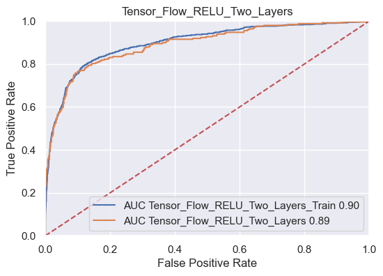

```
Tensor_Flow_RELU_Two_Layers CLASSIFICATION ACCURACY
======
Tensor_Flow_RELU_Two_Layers_Train  =  0.8825503355704698
Tensor_Flow_RELU_Two_Layers  =  0.8783557046979866
------
```

```python
# RELU Two Layers and Dropout Layer
WHO = "Tensor_Flow_RELU_Two_Layers"

U_train = theScaler.transform(X_train)
U_test = theScaler.transform(X_test)

U_train = pd.DataFrame(U_train)
U_test = pd.DataFrame(U_test)

U_train.columns = list(X_train.columns.values)
U_test.columns = list(X_train.columns.values)

U_train = U_train[GB_flag]
U_test = U_test[GB_flag]

F_theShapeSize = U_train.shape[1]
F_theActivation = tf.keras.activations.relu
F_theLossMetric = tf.keras.losses.SparseCategoricalCrossentropy()
F_theOptimizer = tf.keras.optimizers.Adam()
F_theEpochs = 100

F_theUnits = int(2*F_theShapeSize / 3)

F_LAYER_01 = tf.keras.layers.Dense(units=F_theUnits, activation=F_theActivation, input_dim=F_theShapeSize)
F_LAYER_DROP = tf.keras.layers.Dropout(0.2)
F_LAYER_02 = tf.keras.layers.Dense(units=F_theUnits, activation=F_theActivation)
F_LAYER_OUTPUT = tf.keras.layers.Dense(units=2, activation=tf.keras.activations.softmax)

DFT = tf.keras.Sequential()
DFT.add(F_LAYER_01)
DFT.add(F_LAYER_DROP)
DFT.add(F_LAYER_02)
DFT.add(F_LAYER_OUTPUT)
DFT.compile(loss=F_theLossMetric, optimizer=F_theOptimizer)
DFT.fit(U_train, Y_train[TARGET_F], epochs=F_theEpochs, verbose=False)

TRAIN_DFT = get_TF_ProbAccuracyScores(WHO + "_Train", DFT, U_train, Y_train[TARGET_F])
TEST_DFT = get_TF_ProbAccuracyScores(WHO, DFT, U_test, Y_test[TARGET_F])

print_ROC_Curve(WHO, [TRAIN_DFT, TEST_DFT] )
print_Accuracy(WHO + " CLASSIFICATION ACCURACY", [TRAIN_DFT, TEST_DFT])
```

```
30/30 ━━━━━━━━━━━━━━━━━━━━ 0s 3ms/step
8/8 ━━━━━━━━━━━━━━━━━━━━ 0s 4ms/step
Tensor_Flow_RELU_Two_Layers RMSE ACCURACY
======
Tensor_Flow_RELU_Two_Layers_Train  =  4274.104822605811
Tensor_Flow_RELU_Two_Layers  =  4887.915600313919
------
```

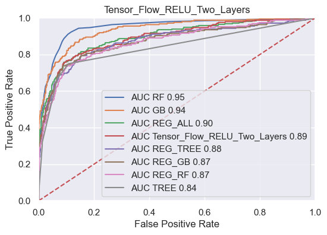

```
ALL CLASSIFICATION ACCURACY
======
RF  =  0.9018456375838926
GB  =  0.9018456375838926
REG_ALL  =  0.8808724832214765
Tensor_Flow_RELU_Two_Layers  =  0.8783557046979866
TREE  =  0.8766778523489933
REG_TREE  =  0.8758389261744967
REG_GB  =  0.8741610738255033
REG_RF  =  0.8674496644295302
------
```

```python
V_train = theScaler.transform(W_train)
V_test = theScaler.transform(W_test)

V_train = pd.DataFrame(V_train)
V_test = pd.DataFrame(V_test)

V_train.columns = list(W_train.columns.values)
V_test.columns = list(W_train.columns.values)

V_train = V_train[GB_amt]
V_test = V_test[GB_amt]

A_theShapeSize = V_train.shape[1]
A_theActivation = tf.keras.activations.relu
A_theLossMetric = tf.keras.losses.MeanSquaredError()
A_theOptimizer = tf.keras.optimizers.Adam()
A_theEpochs = 800

A_theUnits = int(2*A_theShapeSize)

A_LAYER_01 = tf.keras.layers.Dense(units=A_theUnits, activation=A_theActivation, input_dim=A_theShapeSize)
A_LAYER_DROP = tf.keras.layers.Dropout(0.2)
A_LAYER_02 = tf.keras.layers.Dense(units=A_theUnits, activation=A_theActivation)
A_LAYER_OUTPUT = tf.keras.layers.Dense(units=1, activation=tf.keras.activations.linear)

AMT = tf.keras.Sequential()
AMT.add(A_LAYER_01)
AMT.add(A_LAYER_DROP)
AMT.add(A_LAYER_02)
AMT.add(A_LAYER_OUTPUT)
AMT.compile(loss=A_theLossMetric, optimizer=A_theOptimizer)
AMT.fit(V_train, Z_train[TARGET_A], epochs=A_theEpochs, verbose=False)

TRAIN_AMT = getAmtAccuracyScores(WHO + "_Train", AMT, V_train[GB_amt], Z_train[TARGET_A])
TEST_AMT = getAmtAccuracyScores(WHO, AMT, V_test[GB_amt], Z_test[TARGET_A])
print_Accuracy(WHO + " RMSE ACCURACY", [TRAIN_AMT, TEST_AMT])

TF_DFT_RELU_Two_Layers = TEST_DFT.copy()
TF_AMT_RELU_Two_Layers = TEST_AMT.copy()

ALL_DFT = [TREE_DFT, RF_DFT, GB_DFT, REG_ALL_DFT, REG_TREE_DFT, REG_RF_DFT, REG_GB_DFT, TF_DFT_RELU_Two_Layers]

ALL_DFT = sorted(ALL_DFT, key = lambda x: x[4], reverse=True)
print_ROC_Curve(WHO, ALL_DFT)

ALL_DFT = sorted(ALL_DFT, key = lambda x: x[1], reverse=True)
print_Accuracy("ALL CLASSIFICATION ACCURACY", ALL_DFT)
```

```python
ALL_AMT = [TREE_AMT, RF_AMT, GB_AMT, REG_ALL_AMT, REG_TREE_AMT, REG_RF_AMT, REG_GB_AMT, TF_AMT_RELU_Two_Layers]
ALL_AMT = sorted(ALL_AMT, key = lambda x: x[1])
print_Accuracy("ALL DAMAGE MODEL ACCURACY", ALL_AMT)
```

```
ALL DAMAGE MODEL ACCURACY
======
GB  =  4176.186787949678
REG_ALL  =  4523.648027613844
RF  =  4695.811183058997
Tensor_Flow_RELU_Two_Layers  =  4887.915600313919
REG_RF  =  4936.21358051146
REG_GB  =  4936.213580511462
REG_TREE  =  5459.643365660541
TREE  =  6933.346719462516
------
```

```
149/149 ━━━━━━━━━━━━━━━━━━━━ 0s 893us/step
38/38 ━━━━━━━━━━━━━━━━━━━━ 0s 2ms/step
```

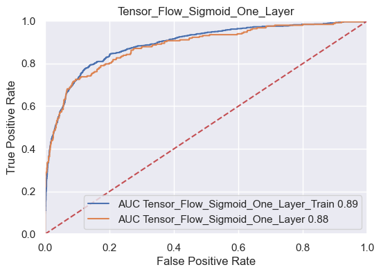

```
Tensor_Flow_Sigmoid_One_Layer CLASSIFICATION ACCURACY
======
Tensor_Flow_Sigmoid_One_Layer_Train  =  0.8777265100671141
Tensor_Flow_Sigmoid_One_Layer  =  0.8741610738255033
------
```

```python
# Sigmoid Activation Function One Layer
WHO = "Tensor_Flow_Sigmoid_One_Layer"

U_train = theScaler.transform(X_train)
U_test = theScaler.transform(X_test)

U_train = pd.DataFrame(U_train)
U_test = pd.DataFrame(U_test)

U_train.columns = list(X_train.columns.values)
U_test.columns = list(X_train.columns.values)

U_train = U_train[GB_flag]
U_test = U_test[GB_flag]

F_theShapeSize = U_train.shape[1]
F_theActivation = tf.keras.activations.sigmoid
F_theLossMetric = tf.keras.losses.SparseCategoricalCrossentropy()
F_theOptimizer = tf.keras.optimizers.Adam()
F_theEpochs = 100

F_theUnits = int(2*F_theShapeSize / 3)

F_LAYER_01 = tf.keras.layers.Dense(units=F_theUnits, activation=F_theActivation, input_dim=F_theShapeSize)
# F_LAYER_DROP = tf.keras.layers.Dropout(0.2)
# F_LAYER_02 = tf.keras.layers.Dense(units=F_theUnits, activation=F_theActivation)
F_LAYER_OUTPUT = tf.keras.layers.Dense(units=2, activation=tf.keras.activations.softmax)

DFT = tf.keras.Sequential()
DFT.add(F_LAYER_01)
# DFT.add(F_LAYER_DROP)
# DFT.add(F_LAYER_02)
DFT.add(F_LAYER_OUTPUT)
DFT.compile(loss=F_theLossMetric, optimizer=F_theOptimizer)
DFT.fit(U_train, Y_train[TARGET_F], epochs=F_theEpochs, verbose=False)

TRAIN_DFT = get_TF_ProbAccuracyScores(WHO + "_Train", DFT, U_train, Y_train[TARGET_F])
TEST_DFT = get_TF_ProbAccuracyScores(WHO, DFT, U_test, Y_test[TARGET_F])

print_ROC_Curve(WHO, [TRAIN_DFT, TEST_DFT] )
print_Accuracy(WHO + " CLASSIFICATION ACCURACY", [TRAIN_DFT, TEST_DFT])
```

```
30/30 ━━━━━━━━━━━━━━━━━━━━ 0s 2ms/step
8/8 ━━━━━━━━━━━━━━━━━━━━ 0s 3ms/step
Tensor_Flow_Sigmoid_One_Layer RMSE ACCURACY
======
Tensor_Flow_Sigmoid_One_Layer_Train  =  9565.211529937787
Tensor_Flow_Sigmoid_One_Layer  =  9562.609279173541
------
```

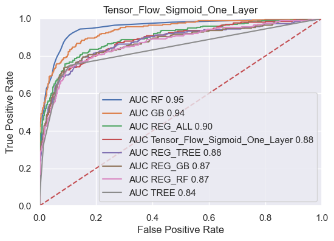

```
ALL CLASSIFICATION ACCURACY
======
RF  =  0.9018456375838926
GB  =  0.9018456375838926
REG_ALL  =  0.8808724832214765
TREE  =  0.8766778523489933
REG_TREE  =  0.8758389261744967
Tensor_Flow_Sigmoid_One_Layer  =  0.8741610738255033
REG_GB  =  0.8741610738255033
REG_RF  =  0.8674496644295302
------
```

```python
V_train = theScaler.transform(W_train)
V_test = theScaler.transform(W_test)

V_train = pd.DataFrame(V_train)
V_test = pd.DataFrame(V_test)

V_train.columns = list(W_train.columns.values)
V_test.columns = list(W_train.columns.values)

V_train = V_train[GB_amt]
V_test = V_test[GB_amt]

A_theShapeSize = V_train.shape[1]
A_theActivation = tf.keras.activations.relu
A_theLossMetric = tf.keras.losses.MeanSquaredError()
A_theOptimizer = tf.keras.optimizers.Adam()
A_theEpochs = 800

A_theUnits = int(2*A_theShapeSize)

A_LAYER_01 = tf.keras.layers.Dense(units=A_theUnits, activation=A_theActivation, input_dim=A_theShapeSize)
# A_LAYER_DROP = tf.keras.layers.Dropout(0.2)
# A_LAYER_02 = tf.keras.layers.Dense(units=A_theUnits, activation=A_theActivation)
A_LAYER_OUTPUT = tf.keras.layers.Dense(units=1, activation=tf.keras.activations.linear)

AMT = tf.keras.Sequential()
AMT.add(A_LAYER_01)
# AMT.add(A_LAYER_DROP)
# AMT.add(A_LAYER_02)
AMT.add(A_LAYER_OUTPUT)
AMT.compile(loss=A_theLossMetric, optimizer=A_theOptimizer)
AMT.fit(V_train, Z_train[TARGET_A], epochs=A_theEpochs, verbose=False)

TRAIN_AMT = getAmtAccuracyScores(WHO + "_Train", AMT, V_train[GB_amt], Z_train[TARGET_A])
TEST_AMT = getAmtAccuracyScores(WHO, AMT, V_test[GB_amt], Z_test[TARGET_A])
print_Accuracy(WHO + " RMSE ACCURACY", [TRAIN_AMT, TEST_AMT])

TF_DFT_Sigmoid_One_Layer = TEST_DFT.copy()
TF_AMT_Sigmoid_One_Layer = TEST_AMT.copy()

ALL_DFT = [TREE_DFT, RF_DFT, GB_DFT, REG_ALL_DFT, REG_TREE_DFT, REG_RF_DFT, REG_GB_DFT, TF_DFT_Sigmoid_One_Layer]

ALL_DFT = sorted(ALL_DFT, key = lambda x: x[4], reverse=True)
print_ROC_Curve(WHO, ALL_DFT)

ALL_DFT = sorted(ALL_DFT, key = lambda x: x[1], reverse=True)
print_Accuracy("ALL CLASSIFICATION ACCURACY", ALL_DFT)
```

```python
ALL_AMT = [TREE_AMT, RF_AMT, GB_AMT, REG_ALL_AMT, REG_TREE_AMT, REG_RF_AMT, REG_GB_AMT, TF_AMT_Sigmoid_One_Layer]
ALL_AMT = sorted(ALL_AMT, key = lambda x: x[1])
print_Accuracy("ALL DAMAGE MODEL ACCURACY", ALL_AMT)
```

```
ALL DAMAGE MODEL ACCURACY
======
GB  =  4176.186787949678
REG_ALL  =  4523.648027613844
RF  =  4695.811183058997
REG_RF  =  4936.21358051146
REG_GB  =  4936.213580511462
REG_TREE  =  5459.643365660541
TREE  =  6933.346719462516
Tensor_Flow_Sigmoid_One_Layer  =  9562.609279173541
------
```

```
149/149 ━━━━━━━━━━━━━━━━━━━━ 0s 1ms/step
38/38 ━━━━━━━━━━━━━━━━━━━━ 0s 2ms/step
```

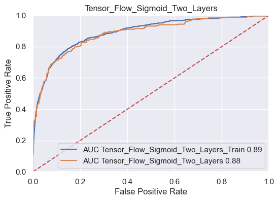

```
Tensor_Flow_Sigmoid_Two_Layers CLASSIFICATION ACCURACY
======
Tensor_Flow_Sigmoid_Two_Layers_Train  =  0.8766778523489933
Tensor_Flow_Sigmoid_Two_Layers  =  0.8708053691275168
------
```

```python
# Sigmoid Activation Function Two Layers
WHO = "Tensor_Flow_Sigmoid_Two_Layers"

U_train = theScaler.transform(X_train)
U_test = theScaler.transform(X_test)

U_train = pd.DataFrame(U_train)
U_test = pd.DataFrame(U_test)

U_train.columns = list(X_train.columns.values)
U_test.columns = list(X_train.columns.values)

U_train = U_train[GB_flag]
U_test = U_test[GB_flag]

F_theShapeSize = U_train.shape[1]
F_theActivation = tf.keras.activations.sigmoid
F_theLossMetric = tf.keras.losses.SparseCategoricalCrossentropy()
F_theOptimizer = tf.keras.optimizers.Adam()
F_theEpochs = 100

F_theUnits = int(2*F_theShapeSize / 3)

F_LAYER_01 = tf.keras.layers.Dense(units=F_theUnits, activation=F_theActivation, input_dim=F_theShapeSize)
F_LAYER_DROP = tf.keras.layers.Dropout(0.2)
F_LAYER_02 = tf.keras.layers.Dense(units=F_theUnits, activation=F_theActivation)
F_LAYER_OUTPUT = tf.keras.layers.Dense(units=2, activation=tf.keras.activations.softmax)

DFT = tf.keras.Sequential()
DFT.add(F_LAYER_01)
DFT.add(F_LAYER_DROP)
DFT.add(F_LAYER_02)
DFT.add(F_LAYER_OUTPUT)
DFT.compile(loss=F_theLossMetric, optimizer=F_theOptimizer)
DFT.fit(U_train, Y_train[TARGET_F], epochs=F_theEpochs, verbose=False)

TRAIN_DFT = get_TF_ProbAccuracyScores(WHO + "_Train", DFT, U_train, Y_train[TARGET_F])
TEST_DFT = get_TF_ProbAccuracyScores(WHO, DFT, U_test, Y_test[TARGET_F])

print_ROC_Curve(WHO, [TRAIN_DFT, TEST_DFT] )
print_Accuracy(WHO + " CLASSIFICATION ACCURACY", [TRAIN_DFT, TEST_DFT])
```

```
30/30 ━━━━━━━━━━━━━━━━━━━━ 0s 3ms/step
8/8 ━━━━━━━━━━━━━━━━━━━━ 0s 4ms/step
Tensor_Flow_Sigmoid_Two_Layers RMSE ACCURACY
======
Tensor_Flow_Sigmoid_Two_Layers_Train  =  4418.775162126988
Tensor_Flow_Sigmoid_Two_Layers  =  4979.362915796373
------
```

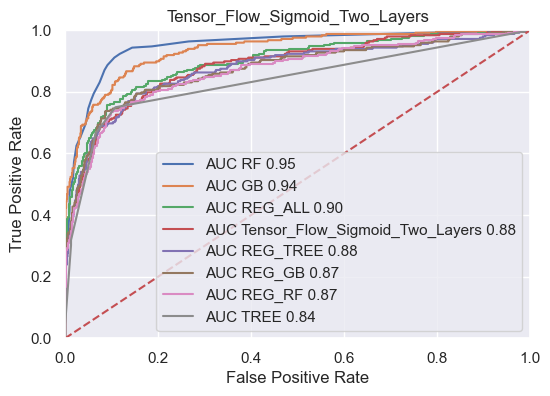

```
ALL CLASSIFICATION ACCURACY
======
RF  =  0.9018456375838926
GB  =  0.9018456375838926
REG_ALL  =  0.8808724832214765
TREE  =  0.8766778523489933
REG_TREE  =  0.8758389261744967
REG_GB  =  0.8741610738255033
Tensor_Flow_Sigmoid_Two_Layers  =  0.8708053691275168
REG_RF  =  0.8674496644295302
------
```

```python
V_train = theScaler.transform(W_train)
V_test = theScaler.transform(W_test)

V_train = pd.DataFrame(V_train)
V_test = pd.DataFrame(V_test)

V_train.columns = list(W_train.columns.values)
V_test.columns = list(W_train.columns.values)

V_train = V_train[GB_amt]
V_test = V_test[GB_amt]

A_theShapeSize = V_train.shape[1]
A_theActivation = tf.keras.activations.relu
A_theLossMetric = tf.keras.losses.MeanSquaredError()
A_theOptimizer = tf.keras.optimizers.Adam()
A_theEpochs = 800

A_theUnits = int(2*A_theShapeSize)

A_LAYER_01 = tf.keras.layers.Dense(units=A_theUnits, activation=A_theActivation, input_dim=A_theShapeSize)
A_LAYER_DROP = tf.keras.layers.Dropout(0.2)
A_LAYER_02 = tf.keras.layers.Dense(units=A_theUnits, activation=A_theActivation)
A_LAYER_OUTPUT = tf.keras.layers.Dense(units=1, activation=tf.keras.activations.linear)

AMT = tf.keras.Sequential()
AMT.add(A_LAYER_01)
AMT.add(A_LAYER_DROP)
AMT.add(A_LAYER_02)
AMT.add(A_LAYER_OUTPUT)
AMT.compile(loss=A_theLossMetric, optimizer=A_theOptimizer)
AMT.fit(V_train, Z_train[TARGET_A], epochs=A_theEpochs, verbose=False)

TRAIN_AMT = getAmtAccuracyScores(WHO + "_Train", AMT, V_train[GB_amt], Z_train[TARGET_A])
TEST_AMT = getAmtAccuracyScores(WHO, AMT, V_test[GB_amt], Z_test[TARGET_A])
print_Accuracy(WHO + " RMSE ACCURACY", [TRAIN_AMT, TEST_AMT])

TF_DFT_Sigmoid_Two_Layers = TEST_DFT.copy()
TF_AMT_Sigmoid_Two_Layers = TEST_AMT.copy()

ALL_DFT = [TREE_DFT, RF_DFT, GB_DFT, REG_ALL_DFT, REG_TREE_DFT, REG_RF_DFT, REG_GB_DFT, TF_DFT_Sigmoid_Two_Layers]

ALL_DFT = sorted(ALL_DFT, key = lambda x: x[4], reverse=True)
print_ROC_Curve(WHO, ALL_DFT)

ALL_DFT = sorted(ALL_DFT, key = lambda x: x[1], reverse=True)
print_Accuracy("ALL CLASSIFICATION ACCURACY", ALL_DFT)
```

```python
ALL_AMT = [TREE_AMT, RF_AMT, GB_AMT, REG_ALL_AMT, REG_TREE_AMT, REG_RF_AMT, REG_GB_AMT, TF_AMT_Sigmoid_Two_Layers]
ALL_AMT = sorted(ALL_AMT, key = lambda x: x[1])
print_Accuracy("ALL DAMAGE MODEL ACCURACY", ALL_AMT)
```

```
ALL DAMAGE MODEL ACCURACY
======
GB  =  4176.186787949678
REG_ALL  =  4523.648027613844
RF  =  4695.811183058997
REG_RF  =  4936.21358051146
REG_GB  =  4936.213580511462
Tensor_Flow_Sigmoid_Two_Layers  =  4979.362915796373
REG_TREE  =  5459.643365660541
TREE  =  6933.346719462516
------
```

```
149/149 ━━━━━━━━━━━━━━━━━━━━ 0s 1ms/step
38/38 ━━━━━━━━━━━━━━━━━━━━ 0s 2ms/step
```

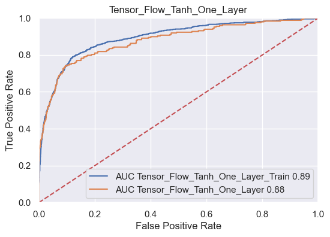

```
Tensor_Flow_Tanh_One_Layer CLASSIFICATION ACCURACY
======
Tensor_Flow_Tanh_One_Layer_Train  =  0.8796140939597316
Tensor_Flow_Tanh_One_Layer  =  0.875
------
```

```python
# Tanh Activation Function One Layer
WHO = "Tensor_Flow_Tanh_One_Layer"

U_train = theScaler.transform(X_train)
U_test = theScaler.transform(X_test)

U_train = pd.DataFrame(U_train)
U_test = pd.DataFrame(U_test)

U_train.columns = list(X_train.columns.values)
U_test.columns = list(X_train.columns.values)

U_train = U_train[GB_flag]
U_test = U_test[GB_flag]

F_theShapeSize = U_train.shape[1]
F_theActivation = tf.keras.activations.tanh
F_theLossMetric = tf.keras.losses.SparseCategoricalCrossentropy()
F_theOptimizer = tf.keras.optimizers.Adam()
F_theEpochs = 100

F_theUnits = int(2*F_theShapeSize / 3)

F_LAYER_01 = tf.keras.layers.Dense(units=F_theUnits, activation=F_theActivation, input_dim=F_theShapeSize)
# F_LAYER_DROP = tf.keras.layers.Dropout(0.2)
# F_LAYER_02 = tf.keras.layers.Dense(units=F_theUnits, activation=F_theActivation)
F_LAYER_OUTPUT = tf.keras.layers.Dense(units=2, activation=tf.keras.activations.softmax)

DFT = tf.keras.Sequential()
DFT.add(F_LAYER_01)
# DFT.add(F_LAYER_DROP)
# DFT.add(F_LAYER_02)
DFT.add(F_LAYER_OUTPUT)
DFT.compile(loss=F_theLossMetric, optimizer=F_theOptimizer)
DFT.fit(U_train, Y_train[TARGET_F], epochs=F_theEpochs, verbose=False)

TRAIN_DFT = get_TF_ProbAccuracyScores(WHO + "_Train", DFT, U_train, Y_train[TARGET_F])
TEST_DFT = get_TF_ProbAccuracyScores(WHO, DFT, U_test, Y_test[TARGET_F])

print_ROC_Curve(WHO, [TRAIN_DFT, TEST_DFT] )
print_Accuracy(WHO + " CLASSIFICATION ACCURACY", [TRAIN_DFT, TEST_DFT])
```

```
30/30 ━━━━━━━━━━━━━━━━━━━━ 0s 2ms/step
8/8 ━━━━━━━━━━━━━━━━━━━━ 0s 3ms/step
Tensor_Flow_Tanh_One_Layer RMSE ACCURACY
======
Tensor_Flow_Tanh_One_Layer_Train  =  12173.71657614565
Tensor_Flow_Tanh_One_Layer  =  11646.445571076614
------
```

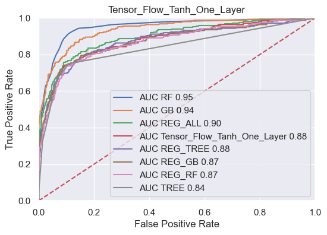

```
ALL CLASSIFICATION ACCURACY
======
RF  =  0.9018456375838926
GB  =  0.9018456375838926
REG_ALL  =  0.8808724832214765
TREE  =  0.8766778523489933
REG_TREE  =  0.8758389261744967
Tensor_Flow_Tanh_One_Layer  =  0.875
REG_GB  =  0.8741610738255033
REG_RF  =  0.8674496644295302
------
```

```python
V_train = theScaler.transform(W_train)
V_test = theScaler.transform(W_test)

V_train = pd.DataFrame(V_train)
V_test = pd.DataFrame(V_test)

V_train.columns = list(W_train.columns.values)
V_test.columns = list(W_train.columns.values)

V_train = V_train[GB_amt]
V_test = V_test[GB_amt]

A_theShapeSize = V_train.shape[1]
A_theActivation = tf.keras.activations.relu
A_theLossMetric = tf.keras.losses.MeanSquaredError()
A_theOptimizer = tf.keras.optimizers.Adam()
A_theEpochs = 800

A_theUnits = int(2*A_theShapeSize)

A_LAYER_01 = tf.keras.layers.Dense(units=A_theUnits, activation=A_theActivation, input_dim=A_theShapeSize)
# A_LAYER_DROP = tf.keras.layers.Dropout(0.2)
# A_LAYER_02 = tf.keras.layers.Dense(units=A_theUnits, activation=A_theActivation)
A_LAYER_OUTPUT = tf.keras.layers.Dense(units=1, activation=tf.keras.activations.linear)

AMT = tf.keras.Sequential()
AMT.add(A_LAYER_01)
# AMT.add(A_LAYER_DROP)
# AMT.add(A_LAYER_02)
AMT.add(A_LAYER_OUTPUT)
AMT.compile(loss=A_theLossMetric, optimizer=A_theOptimizer)
AMT.fit(V_train, Z_train[TARGET_A], epochs=A_theEpochs, verbose=False)

TRAIN_AMT = getAmtAccuracyScores(WHO + "_Train", AMT, V_train[GB_amt], Z_train[TARGET_A])
TEST_AMT = getAmtAccuracyScores(WHO, AMT, V_test[GB_amt], Z_test[TARGET_A])
print_Accuracy(WHO + " RMSE ACCURACY", [TRAIN_AMT, TEST_AMT])

TF_DFT_Tanh_One_Layer = TEST_DFT.copy()
TF_AMT_Tanh_One_Layer = TEST_AMT.copy()

ALL_DFT = [TREE_DFT, RF_DFT, GB_DFT, REG_ALL_DFT, REG_TREE_DFT, REG_RF_DFT, REG_GB_DFT, TF_DFT_Tanh_One_Layer]

ALL_DFT = sorted(ALL_DFT, key = lambda x: x[4], reverse=True)
print_ROC_Curve(WHO, ALL_DFT)

ALL_DFT = sorted(ALL_DFT, key = lambda x: x[1], reverse=True)
print_Accuracy("ALL CLASSIFICATION ACCURACY", ALL_DFT)
```

```python
ALL_AMT = [TREE_AMT, RF_AMT, GB_AMT, REG_ALL_AMT, REG_TREE_AMT, REG_RF_AMT, REG_GB_AMT, TF_AMT_Tanh_One_Layer]
ALL_AMT = sorted(ALL_AMT, key = lambda x: x[1])
print_Accuracy("ALL DAMAGE MODEL ACCURACY", ALL_AMT)
```

```
ALL DAMAGE MODEL ACCURACY
======
GB  =  4176.186787949678
REG_ALL  =  4523.648027613844
RF  =  4695.811183058997
REG_RF  =  4936.21358051146
REG_GB  =  4936.213580511462
REG_TREE  =  5459.643365660541
TREE  =  6933.346719462516
Tensor_Flow_Tanh_One_Layer  =  11646.445571076614
------
```

```
149/149 ━━━━━━━━━━━━━━━━━━━━ 0s 924us/step
38/38 ━━━━━━━━━━━━━━━━━━━━ 0s 2ms/step
```

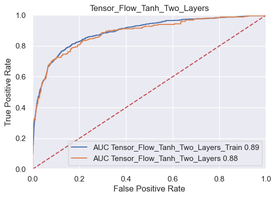

```
Tensor_Flow_Tanh_Two_Layers CLASSIFICATION ACCURACY
======
Tensor_Flow_Tanh_Two_Layers_Train  =  0.8762583892617449
Tensor_Flow_Tanh_Two_Layers  =  0.875
------
```

```python
# Tanh Activation Function Two Layers
WHO = "Tensor_Flow_Tanh_Two_Layers"

U_train = theScaler.transform(X_train)
U_test = theScaler.transform(X_test)

U_train = pd.DataFrame(U_train)
U_test = pd.DataFrame(U_test)

U_train.columns = list(X_train.columns.values)
U_test.columns = list(X_train.columns.values)

U_train = U_train[GB_flag]
U_test = U_test[GB_flag]

F_theShapeSize = U_train.shape[1]
F_theActivation = tf.keras.activations.sigmoid
F_theLossMetric = tf.keras.losses.SparseCategoricalCrossentropy()
F_theOptimizer = tf.keras.optimizers.Adam()
F_theEpochs = 100

F_theUnits = int(2*F_theShapeSize / 3)

F_LAYER_01 = tf.keras.layers.Dense(units=F_theUnits, activation=F_theActivation, input_dim=F_theShapeSize)
F_LAYER_DROP = tf.keras.layers.Dropout(0.2)
F_LAYER_02 = tf.keras.layers.Dense(units=F_theUnits, activation=F_theActivation)
F_LAYER_OUTPUT = tf.keras.layers.Dense(units=2, activation=tf.keras.activations.softmax)

DFT = tf.keras.Sequential()
DFT.add(F_LAYER_01)
DFT.add(F_LAYER_DROP)
DFT.add(F_LAYER_02)
DFT.add(F_LAYER_OUTPUT)
DFT.compile(loss=F_theLossMetric, optimizer=F_theOptimizer)
DFT.fit(U_train, Y_train[TARGET_F], epochs=F_theEpochs, verbose=False)

TRAIN_DFT = get_TF_ProbAccuracyScores(WHO + "_Train", DFT, U_train, Y_train[TARGET_F])
TEST_DFT = get_TF_ProbAccuracyScores(WHO, DFT, U_test, Y_test[TARGET_F])

print_ROC_Curve(WHO, [TRAIN_DFT, TEST_DFT] )
print_Accuracy(WHO + " CLASSIFICATION ACCURACY", [TRAIN_DFT, TEST_DFT])
```

```
30/30 ━━━━━━━━━━━━━━━━━━━━ 0s 3ms/step
8/8 ━━━━━━━━━━━━━━━━━━━━ 0s 4ms/step
Tensor_Flow_Tanh_Two_Layers RMSE ACCURACY
======
Tensor_Flow_Tanh_Two_Layers_Train  =  4310.602415505209
Tensor_Flow_Tanh_Two_Layers  =  4912.487818258887
------
```

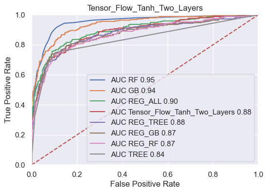

```
ALL CLASSIFICATION ACCURACY
======
RF  =  0.9018456375838926
GB  =  0.9018456375838926
REG_ALL  =  0.8808724832214765
TREE  =  0.8766778523489933
REG_TREE  =  0.8758389261744967
Tensor_Flow_Tanh_Two_Layers  =  0.875
REG_GB  =  0.8741610738255033
REG_RF  =  0.8674496644295302
------
```

```python
V_train = theScaler.transform(W_train)
V_test = theScaler.transform(W_test)

V_train = pd.DataFrame(V_train)
V_test = pd.DataFrame(V_test)

V_train.columns = list(W_train.columns.values)
V_test.columns = list(W_train.columns.values)

V_train = V_train[GB_amt]
V_test = V_test[GB_amt]

A_theShapeSize = V_train.shape[1]
A_theActivation = tf.keras.activations.relu
A_theLossMetric = tf.keras.losses.MeanSquaredError()
A_theOptimizer = tf.keras.optimizers.Adam()
A_theEpochs = 800

A_theUnits = int(2*A_theShapeSize)

A_LAYER_01 = tf.keras.layers.Dense(units=A_theUnits, activation=A_theActivation, input_dim=A_theShapeSize)
A_LAYER_DROP = tf.keras.layers.Dropout(0.2)
A_LAYER_02 = tf.keras.layers.Dense(units=A_theUnits, activation=A_theActivation)
A_LAYER_OUTPUT = tf.keras.layers.Dense(units=1, activation=tf.keras.activations.linear)

AMT = tf.keras.Sequential()
AMT.add(A_LAYER_01)
AMT.add(A_LAYER_DROP)
AMT.add(A_LAYER_02)
AMT.add(A_LAYER_OUTPUT)
AMT.compile(loss=A_theLossMetric, optimizer=A_theOptimizer)
AMT.fit(V_train, Z_train[TARGET_A], epochs=A_theEpochs, verbose=False)

TRAIN_AMT = getAmtAccuracyScores(WHO + "_Train", AMT, V_train[GB_amt], Z_train[TARGET_A])
TEST_AMT = getAmtAccuracyScores(WHO, AMT, V_test[GB_amt], Z_test[TARGET_A])
print_Accuracy(WHO + " RMSE ACCURACY", [TRAIN_AMT, TEST_AMT])

TF_DFT_Tanh_Two_Layers = TEST_DFT.copy()
TF_AMT_Tanh_Two_Layers = TEST_AMT.copy()

ALL_DFT = [TREE_DFT, RF_DFT, GB_DFT, REG_ALL_DFT, REG_TREE_DFT, REG_RF_DFT, REG_GB_DFT, TF_DFT_Tanh_Two_Layers]

ALL_DFT = sorted(ALL_DFT, key = lambda x: x[4], reverse=True)
print_ROC_Curve(WHO, ALL_DFT)

ALL_DFT = sorted(ALL_DFT, key = lambda x: x[1], reverse=True)
print_Accuracy("ALL CLASSIFICATION ACCURACY", ALL_DFT)
```

```python
ALL_AMT = [TREE_AMT, RF_AMT, GB_AMT, REG_ALL_AMT, REG_TREE_AMT, REG_RF_AMT, REG_GB_AMT, TF_AMT_Tanh_Two_Layers]
ALL_AMT = sorted(ALL_AMT, key = lambda x: x[1])
print_Accuracy("ALL DAMAGE MODEL ACCURACY", ALL_AMT)
```

```
ALL DAMAGE MODEL ACCURACY
======
GB  =  4176.186787949678
REG_ALL  =  4523.648027613844
RF  =  4695.811183058997
Tensor_Flow_Tanh_Two_Layers  =  4912.487818258887
REG_RF  =  4936.21358051146
REG_GB  =  4936.213580511462
REG_TREE  =  5459.643365660541
TREE  =  6933.346719462516
------
```

```python
#Comparing All Tensor Flow Models
```

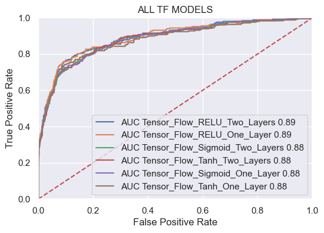

```
ALL TF CLASSIFICATION ACCURACY
======
Tensor_Flow_RELU_One_Layer  =  0.8800335570469798
Tensor_Flow_RELU_Two_Layers  =  0.8783557046979866
Tensor_Flow_Tanh_Two_Layers  =  0.875
Tensor_Flow_Tanh_One_Layer  =  0.875
Tensor_Flow_Sigmoid_One_Layer  =  0.8741610738255033
Tensor_Flow_Sigmoid_Two_Layers  =  0.8708053691275168
------
```

```python
ALL_TF_DFT = [TF_DFT_RELU_One_Layer, TF_DFT_RELU_Two_Layers,TF_DFT_Sigmoid_One_Layer,TF_DFT_Sigmoid_Two_Layers, TF_DFT_Tanh_One_Layer, TF_DFT_Tanh_Two_Layers]

ALL_TF_DFT = sorted(ALL_TF_DFT, key = lambda x: x[4], reverse=True)
print_ROC_Curve("ALL TF MODELS", ALL_TF_DFT)

ALL_TF_DFT = sorted(ALL_TF_DFT, key = lambda x: x[1], reverse=True)
print_Accuracy("ALL TF CLASSIFICATION ACCURACY", ALL_TF_DFT)
```

Similarly, a comparison of all six TensorFlow (neural network) models can be seen below. It is interesting to see that the models with two layers and a drop layer significantly outperformed the single layer models without a drop layer. This, logically, makes sense because the models are more complex and better trained, which would make them perform better. All three two-layer models performed about the same, and if picking one to go into production in the real world, all three could be interchangeable. However, because the RELU model performed the best (even if very slightly), I would choose that model.

```python
ALL_TF_AMT = [TF_AMT_RELU_One_Layer, TF_AMT_RELU_Two_Layers,TF_AMT_Sigmoid_One_Layer,TF_AMT_Sigmoid_Two_Layers, TF_AMT_Tanh_One_Layer, TF_AMT_Tanh_Two_Layers]
ALL_TF_AMT = sorted(ALL_TF_AMT, key = lambda x: x[1])
print_Accuracy("ALL TF DAMAGE MODEL ACCURACY", ALL_TF_AMT)
```

```
ALL TF DAMAGE MODEL ACCURACY
======
Tensor_Flow_RELU_Two_Layers  =  4887.915600313919
Tensor_Flow_Tanh_Two_Layers  =  4912.487818258887
Tensor_Flow_Sigmoid_Two_Layers  =  4979.362915796373
Tensor_Flow_Sigmoid_One_Layer  =  9562.609279173541
Tensor_Flow_RELU_One_Layer  =  9572.61854180645
Tensor_Flow_Tanh_One_Layer  =  11646.445571076614
------
```